# Project Overview

The Starbucks project is coming out from customer marketing domain. Traditional marketing analytics or scoreboards are essential for evaluating the success or failure of organization’s past marketing activities. But today's marketers or organizations can leverage advanced marketing techniques like predictive modeling for customer behavior, predictive lead scoring, and all sorts of strategies based on predictive analytics insights. Various Cases for Predictive Marketing Analytics are:

- 1- Upselling and Cross-Selling Readiness.
- 2 - Understanding Product Fit
- 3- Optimization of Marketing Campaigns.

In this Project, we would deal with the case of ‘Optimization of Marketing Campaigns’. Predictive techniques can make an organization marketing investment much more efficient and helps in regularly validating results. Connecting customer information to the operational data provides valuable insight into customer behavior and the health of your overall business.

Refer below links in order to have better understanding of the impact of predictive analytics for better marketing performance.

- 1- Predictive Analytics: What it is and why it matters
- 2- Marketing Analytics for Data-Rich Environments
- 3- How to Use Predictive Analytics for Better Marketing Performance
- In this project, we would go through the predictive modeling technique for customer behavior through Starbucks dataset example. Starbucks provided simulated data that mimics customer behavior on the Starbucks rewards mobile app. Once every few days, Starbucks sends out an offer to users of the mobile app. An offer can be merely an advertisement for a drink or an actual offer such as a discount or BOGO (buy one get one free). Some users might not receive any offer during certain weeks. Not all users receive the same offer, and this data set is a simplified version of the real Starbucks app because the underlying simulator only has one product whereas Starbucks actually sells dozens of products.
- In this project, Starbucks wants to connect offer data, customer data and transaction data (operational data) to gain insights about customer behavior and overall effectiveness of offers as a value for business. With the above key statement in mind, we can determine the main objective or problem motivation or problem statement

# Problem statement

Identifying which groups of people are most responsive to each type of offer, and how best to present each type of offer.

Above problem is classification problem to determine the type of offer that each customer will be most responsive to. To solve this problem Starbucks give simulated data about one product Also we can answer specific questions for example.

1 – how much should customer pay in each offer

# Data Sets

- The program used to create the data simulates how people make purchasing decisions and how those decisions are influenced by promotional offers.
- Each person in the simulation has some hidden traits that influence their purchasing patterns and are associated with their observable traits. People produce various events, including receiving offers, opening offers, and making purchases.
- As a simplification, there are no explicit products to track. Only the amounts of each transaction or offer are recorded.
- There are three types of offers that can be sent: buy-one-get-one (BOGO), discount, and informational. In a BOGO offer, a user needs to spend a certain amount to get a reward equal to that threshold amount.In adiscount, a user gains a reward equal to a fraction of the amount spent. In an informational offer, there is no reward, but neither is there a requisite amount that the user is expected to spend. Offers can be delivered via multiple channels.
- The basic task is to use the data to identify which groups of people are most responsive to each type of offer, and how best to present each type of offer.

The data is contained in three files:

- portfolio.json - containing offer ids and meta data about each offer (duration, type, etc.)
- profile.json - demographic data for each customer
- transcript.json - records for transactions, offers received, offers viewed, and offers completed

Here is the schema and explanation of each variable in the files:

**portfolio.json**

- id (string) - offer id
- offer_type (string) - type of offer ie BOGO, discount, informational
- difficulty (int) - minimum required spend to complete an offer
- reward (int) - reward given for completing an offer
- duration (int) - time for offer to be open, in days
- channels (list of strings)

**profile.json**

- age (int) - age of the customer
- became_member_on (int) - date when customer created an app account
- gender (str) - gender of the customer (note some entries contain 'O' for other rather than M or F)
- id (str) - customer id
- income (float) - customer's income

**transcript.json**

- event (str) - record description (ie transaction, offer received, offer viewed, etc.)
- person (str) - customer id
- time (int) - time in hours since start of test. The data begins at time t=0
- value - (dict of strings) - either an offer id or transaction amount depending on the record

# Solution Statement

- We will approach this problem using supervised learning technique (classification techniques) to merged portfolio and transcript data after data cleaning and statistical analysis.
- We will evaluate classification models on f1 score metric

## Importing Necessary Libraries

```python
import pandas as pd
import numpy as np
import matplotlib.pyplot as plt
%matplotlib inline
from datetime import datetime
import seaborn as sns
import os
import time

import json
```

```python
from sklearn.preprocessing import StandardScaler, MinMaxScaler
from sklearn.model_selection import train_test_split
from sklearn.linear_model import LogisticRegression
from sklearn.ensemble import RandomForestClassifier, AdaBoostClassifier, GradientBoostingClassifier
from sklearn.model_selection import GridSearchCV
from sklearn.metrics import f1_score, precision_score, recall_score, confusion_matrix
from sklearn.utils.multiclass import unique_labels
```

```python
from sklearn.metrics import make_scorer
```

```python
from sklearn.svm import SVC
```

```python
import scipy
```

```python
import statsmodels.formula.api as smf
import statsmodels.stats.multicomp as multi
```

# Loading data

```python
profile = pd.read_json('profile.json' , orient = 'records', lines  = True)
portfolio = pd.read_json('portfolio.json' , orient = 'records' , lines  = True )
transcript = pd.read_json('transcript.json' , orient = 'records' , lines  = True )
```

# Portfolio data exploration

```python
portfolio
```

|  | channels | difficulty | duration | id | offer_type | reward |
| --- | --- | --- | --- | --- | --- | --- |
| 0 | [email, mobile, social] | 10 | 7 | ae264e3637204a6fb9bb56bc8210ddfd | bogo | 10 |
| 1 | [web, email, mobile, social] | 10 | 5 | 4d5c57ea9a6940dd891ad53e9dbe8da0 | bogo | 10 |
| 2 | [web, email, mobile] | 0 | 4 | 3f207df678b143eea3cee63160fa8bed | informational | 0 |
| 3 | [web, email, mobile] | 5 | 7 | 9b98b8c7a33c4b65b9aebfe6a799e6d9 | bogo | 5 |
| 4 | [web, email] | 20 | 10 | 0b1e1539f2cc45b7b9fa7c272da2e1d7 | discount | 5 |
| 5 | [web, email, mobile, social] | 7 | 7 | 2298d6c36e964ae4a3e7e9706d1fb8c2 | discount | 3 |
| 6 | [web, email, mobile, social] | 10 | 10 | fafdcd668e3743c1bb461111dcafc2a4 | discount | 2 |
| 7 | [email, mobile, social] | 0 | 3 | 5a8bc65990b245e5a138643cd4eb9837 | informational | 0 |
| 8 | [web, email, mobile, social] | 5 | 5 | f19421c1d4aa40978ebb69ca19b0e20d | bogo | 5 |
| 9 | [web, email, mobile] | 10 | 7 | 2906b810c7d4411798c6938adc9daaa5 | discount | 2 |

Renaming offer id

```python
portfolio.rename(columns = {'id':'offer_id'}, inplace = True)
```

Counting number of each offer type

```python
portfolio.groupby(by = 'offer_type' ,axis = 0  )[['offer_id']].count()
```

| offer_type | offer_id |
| --- | --- |
| bogo | 4 |
| discount | 4 |
| informational | 2 |

We see that we have 4 bogo offer type , 4 discount offer type and 2 informational offer type

We need to create a variable for each type as this will be necessary for machine learning model

```python
portfolio = pd.get_dummies(data = portfolio , columns = ['offer_type'])
```

```python
portfolio.head()
```

|  | channels | difficulty | duration | offer_id | reward | offer_type_bogo | offer_type_discount | offer_type_informational |
| --- | --- | --- | --- | --- | --- | --- | --- | --- |
| 0 | [email, mobile, social] | 10 | 7 | ae264e3637204a6fb9bb56bc8210ddfd | 10 | 1 | 0 | 0 |
| 1 | [web, email, mobile, social] | 10 | 5 | 4d5c57ea9a6940dd891ad53e9dbe8da0 | 10 | 1 | 0 | 0 |
| 2 | [web, email, mobile] | 0 | 4 | 3f207df678b143eea3cee63160fa8bed | 0 | 0 | 0 | 1 |
| 3 | [web, email, mobile] | 5 | 7 | 9b98b8c7a33c4b65b9aebfe6a799e6d9 | 5 | 1 | 0 | 0 |
| 4 | [web, email] | 20 | 10 | 0b1e1539f2cc45b7b9fa7c272da2e1d7 | 5 | 0 | 1 | 0 |

These functions are needed to create dummy variables for channels feature

```python
def create_email_column(val):
    if 'email' in val:
        return 1
    else:
        return 0

def create_mobile_column(val):
    if 'mobile' in val:
        return 1
    else:
        return 0
def create_social_column(val):
    if 'social' in val:
        return 1
    else:
        return 0
def create_web_column(val):
    if 'web' in val:
        return 1
    else:
        return 0
```

```python
create_web_column(['email','social'])
```

```
0
```

```python
portfolio['web']=portfolio['channels'].apply(lambda x: create_web_column(x))
portfolio['email']=portfolio['channels'].apply(lambda x: create_email_column(x))
portfolio['social']=portfolio['channels'].apply(lambda x: create_social_column(x))
portfolio['mobile']=portfolio['channels'].apply(lambda x: create_mobile_column(x))
```

```python
portfolio.head()
```

[output not shown]

# Profile data exploration

```python
profile.head(4)
```

|  | age | became_member_on | gender | id | income |
| --- | --- | --- | --- | --- | --- |
| 0 | 118 | 20170212 | None | 68be06ca386d4c31939f3a4f0e3dd783 | NaN |
| 1 | 55 | 20170715 | F | 0610b486422d4921ae7d2bf64640c50b | 112000.0 |
| 2 | 118 | 20180712 | None | 38fe809add3b4fcf9315a9694bb96ff5 | NaN |
| 3 | 75 | 20170509 | F | 78afa995795e4d85b5d9ceeca43f5fef | 100000.0 |

```python
profile.info()
```

[output not shown]

- We can see that there are nan values and none values in income and gender columns respectively
- Also. suspiction about age value 118 that need further analysis but first we need further to rename user id to user_id we can suspect that these are correlated with users that have NaN income values and None gender value
- We need to adjust became_member_on values

```python
profile.rename(columns = {'id':'user_id'},inplace = True)
```

```python
profile['gender'].value_counts(normalize =True)
```

```
M    0.572277
F    0.413423
O    0.014300
Name: gender, dtype: float64
```

```python
user_118 = profile[profile['age']==118]['user_id']
```

```python
user_118.count()
```

```
2175
```

```python
profile[profile['age']== 118]['gender']
```

```
0        None
2        None
4        None
6        None
7        None
9        None
10       None
11       None
17       None
23       None
26       None
36       None
39       None
44       None
45       None
```

[output cut: 47 more lines]

We can see that the user of age 118 are those have none value in gender feature

```python
profile['gender'].isna().sum()
```

```
2175
```

```python
profile.dropna(axis = 0 , inplace = True)
```

```python
profile.info()
```

```
<class 'pandas.core.frame.DataFrame'>
Int64Index: 14825 entries, 1 to 16999
Data columns (total 5 columns):
age                 14825 non-null int64
became_member_on    14825 non-null int64
gender              14825 non-null object
user_id             14825 non-null object
income              14825 non-null float64
dtypes: float64(1), int64(2), object(2)
memory usage: 694.9+ KB
```

```python
summary_stat = profile.age.describe()
summary_stat
```

```
count    14825.000000
mean        54.393524
std         17.383705
min         18.000000
25%         42.000000
50%         55.000000
75%         66.000000
max        101.000000
Name: age, dtype: float64
```

we need to check if we have outliers and we do so by using IQR

```python
Q1 = summary_stat['25%']
Q3 = summary_stat['75%']
IQR = Q3 - Q1
upper_limit = Q3 + 1.5*IQR
lower_limit = Q1 - 1.5*IQR
```

```python
profile[profile.age>upper_limit].count()
```

```
age                 0
became_member_on    0
gender              0
user_id             0
income              0
dtype: int64
```

```python
profile[profile.age<lower_limit].count()
```

```
age                 0
became_member_on    0
gender              0
user_id             0
income              0
dtype: int64
```

We can see that we don't have any outliers in data

```python
profile['became_member_on'] = pd.to_datetime(profile['became_member_on'],exact = True , format = '%Y%m%d')
```

```python
profile.info()
```

```
<class 'pandas.core.frame.DataFrame'>
Int64Index: 14825 entries, 1 to 16999
Data columns (total 5 columns):
age                 14825 non-null int64
became_member_on    14825 non-null datetime64[ns]
gender              14825 non-null object
user_id             14825 non-null object
income              14825 non-null float64
dtypes: datetime64[ns](1), float64(1), int64(1), object(2)
memory usage: 694.9+ KB
```

```python
profile['became_member_on'].sample(10)
```

```
16338   2017-10-24
10464   2017-07-31
9321    2016-05-20
875     2018-04-13
12959   2018-06-28
2036    2018-04-11
16083   2013-09-06
4915    2016-03-12
2975    2016-07-07
15152   2017-01-01
Name: became_member_on, dtype: datetime64[ns]
```

```python
color = sns.color_palette()[0]
```

```python
profile['became_member_on'].dt.year.value_counts(normalize = True)
```

```
2017    0.377673
2018    0.247487
2016    0.203980
2015    0.107723
2014    0.044654
2013    0.018482
Name: became_member_on, dtype: float64
```

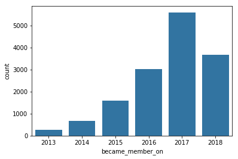

```python
sns.countplot(profile['became_member_on'].dt.year , color = color)
```

WE can see that 2017 has the highest number of customers and then there is a drop in 2018

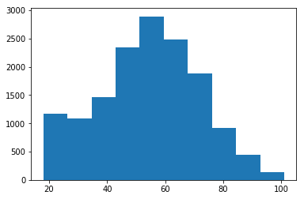

```python
plt.hist(x = profile['age'])
```

# statistical analysis of relation between gender of user and the year he became member user of the reward app

```python
ct1=pd.crosstab(profile['gender'], profile['became_member_on'].dt.year)
print (ct1)

# column percentages
colsum=ct1.sum(axis=0)
colpct=ct1/colsum
print(colpct)
```

```
became_member_on  2013  2014  2015  2016  2017  2018
gender
F                   74   138   663  1509  2443  1302
M                  197   520   905  1483  3067  2312
O                    3     4    29    32    89    55
became_member_on      2013      2014      2015      2016      2017      2018
gender
F                 0.270073  0.208459  0.415153  0.499008  0.436328  0.354865
M                 0.718978  0.785498  0.566688  0.490410  0.547776  0.630144
O                 0.010949  0.006042  0.018159  0.010582  0.015896  0.014990
```

```python
print ('chi-square value, p value, expected counts')
cs1= scipy.stats.chi2_contingency(ct1)
print (cs1)
```

```
chi-square value, p value, expected counts
(306.8316553046649, 5.584944295530618e-60, 10, array([[ 113.27797639,  273.68620573,  660.23696459, 1250.19197302,
        2314.75689713, 1516.84998314],
       [ 156.8037774 ,  378.84708263,  913.9256661 , 1730.56431703,
        3204.17645868, 2099.68269815],
       [   3.91824621,    9.46671164,   22.83736931,   43.24370995,
          80.06664418,   52.46731872]]))
```

As we see that p value 5.58e-60 is very small so we can see that there is a dependency between year of when use bacame member on and gender of the use

# statistical analysis of relation between age and income

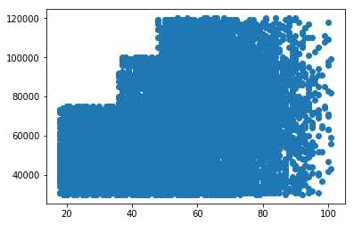

```python
plt.scatter(data = profile ,x = 'age' , y ='income' , color  = color)
```

```python
print ('association Age and income')
print (scipy.stats.pearsonr(profile['age'], profile['income']))
```

```
association Age and income
(0.30670278856125527, 2.2307e-320)
```

# statistical analysis of relation between gender and income

```python
model2 = smf.ols(formula='income ~ C(gender)', data=profile).fit()
print (model2.summary())
```

```
                            OLS Regression Results
==============================================================================
Dep. Variable:                 income   R-squared:                       0.053
Model:                            OLS   Adj. R-squared:                  0.053
Method:                 Least Squares   F-statistic:                     412.7
Date:                Tue, 03 Nov 2020   Prob (F-statistic):          3.68e-175
Time:                        07:29:08   Log-Likelihood:            -1.6859e+05
No. Observations:               14825   AIC:                         3.372e+05
Df Residuals:                   14822   BIC:                         3.372e+05
Df Model:                           2
Covariance Type:            nonrobust
==================================================================================
                     coef    std err          t      P>|t|      [0.025      0.975]
----------------------------------------------------------------------------------
Intercept       7.131e+04    268.525    265.548      0.000    7.08e+04    7.18e+04
C(gender)[T.M] -1.011e+04    352.415    -28.693      0.000   -1.08e+04   -9421.033
C(gender)[T.O] -8018.6763   1468.576     -5.460      0.000   -1.09e+04   -5140.085
==============================================================================
Omnibus:                      551.440   Durbin-Watson:                   1.973
Prob(Omnibus):                  0.000   Jarque-Bera (JB):              455.698
Skew:                           0.355   Prob(JB):                     1.11e-99
Kurtosis:                       2.517   Cond. No.                         10.1
==============================================================================

Warnings:
[1] Standard Errors assume that the covariance matrix of the errors is correctly specified.
```

```python
model2.pvalues
```

```
Intercept          0.000000e+00
C(gender)[T.M]    2.955096e-176
C(gender)[T.O]     4.833304e-08
dtype: float64
```

WE can say from p-values that we have dependency between income of user and gender of user

```python
mc1 = multi.MultiComparison(profile['income'], profile['gender'])
res1 = mc1.tukeyhsd()
print(res1.summary())
```

```
   Multiple Comparison of Means - Tukey HSD,FWER=0.05
=======================================================
group1 group2   meandiff     lower      upper    reject
-------------------------------------------------------
  F      M    -10111.8105 -10937.8521 -9285.769   True
  F      O     -8018.6763 -11460.9348 -4576.4178  True
  M      O     2093.1342   -1333.1142 5519.3827  False
-------------------------------------------------------
```

So data provide enough evidence to reject hypothesis that male and female has the same income mean Also, reject that Female and O have the same income mean

# Transcript data exploration

```python
transcript.sample(7)
```

|  | event | person | time | value |
| --- | --- | --- | --- | --- |
| 93125 | offer completed | a3aab03d52bc4927a6c4eb9c1f9820d8 | 240 | {'offer_id': '9b98b8c7a33c4b65b9aebfe6a799e6d9... |
| 177189 | transaction | 447140e4760b4faf9551166cb9935058 | 426 | {'amount': 26.65} |
| 174025 | offer completed | 585c5622c6344b8cb9f9ce80157b8776 | 420 | {'offer_id': '4d5c57ea9a6940dd891ad53e9dbe8da0... |
| 88761 | transaction | 176d29d85df847a090aae1b8ac24f87d | 222 | {'amount': 6.74} |
| 218937 | offer completed | 0020c2b971eb4e9188eac86d93036a77 | 510 | {'offer_id': '4d5c57ea9a6940dd891ad53e9dbe8da0... |
| 275163 | transaction | d0540651808d4cf298641de8d87b61df | 606 | {'amount': 15.95} |
| 286151 | offer viewed | e93fb1a740ef4f6fa8f98d7c82492ad0 | 636 | {'offer id': '4d5c57ea9a6940dd891ad53e9dbe8da0'} |

We must remove records for user that have age of 118 that exist in user_118 variable

```python
transcript['person'].isin(user_118).value_counts()
```

```
False    272762
True      33772
Name: person, dtype: int64
```

We see that there are a grat number of users in transcript data that have age of 118 we we need to remove records of these users

```python
clean_transcript = transcript[ ~transcript['person'].isin(user_118)]
```

```python
clean_transcript.info()
```

```
<class 'pandas.core.frame.DataFrame'>
Int64Index: 272762 entries, 0 to 306532
Data columns (total 4 columns):
event     272762 non-null object
person    272762 non-null object
time      272762 non-null int64
value     272762 non-null object
dtypes: int64(1), object(3)
memory usage: 10.4+ MB
```

- We need to separate part of data that have transaction events from those don't have an offer
- we need ro create amount column for transaction data and offer_id for records that have offer
- we need to remove duplicated in each data

```python
def create_offer_id_column(val):

    if list(val.keys())[0]in ['offer_id' ,'offer id']:

        return list(val.values())[0]

def create_amount_column(val):

    if list(val.keys())[0]in ['amount']:

        return list(val.values())[0]
```

```python
value = create_amount_column({'amount': 21.51})
print(value)
```

```
21.51
```

```python
transaction_df = clean_transcript[clean_transcript['event'] =='transaction']
offer_df = clean_transcript[clean_transcript['event'] != 'transaction']
```

```python
transaction_df['amount'] = transaction_df['value'].apply(lambda x: create_amount_column(x))
```

```
C:\Users\eng basel\Anaconda3\lib\site-packages\ipykernel_launcher.py:1: SettingWithCopyWarning:
A value is trying to be set on a copy of a slice from a DataFrame.
Try using .loc[row_indexer,col_indexer] = value instead

See the caveats in the documentation: http://pandas.pydata.org/pandas-docs/stable/indexing.html#indexing-view-versus-copy
  """Entry point for launching an IPython kernel.
```

```python
transaction_df.drop(labels = ['value' , 'event'], axis = 1 , inplace = True)
transaction_df.head()
```

```
C:\Users\eng basel\Anaconda3\lib\site-packages\ipykernel_launcher.py:1: SettingWithCopyWarning:
A value is trying to be set on a copy of a slice from a DataFrame

See the caveats in the documentation: http://pandas.pydata.org/pandas-docs/stable/indexing.html#indexing-view-versus-copy
  """Entry point for launching an IPython kernel.
```

|  | person | time | amount |
| --- | --- | --- | --- |
| 12654 | 02c083884c7d45b39cc68e1314fec56c | 0 | 0.83 |
| 12657 | 9fa9ae8f57894cc9a3b8a9bbe0fc1b2f | 0 | 34.56 |
| 12659 | 54890f68699049c2a04d415abc25e717 | 0 | 13.23 |
| 12670 | b2f1cd155b864803ad8334cdf13c4bd2 | 0 | 19.51 |
| 12671 | fe97aa22dd3e48c8b143116a8403dd52 | 0 | 18.97 |

```python
transaction_df.drop_duplicates(inplace= True)
```

```
C:\Users\eng basel\Anaconda3\lib\site-packages\ipykernel_launcher.py:1: SettingWithCopyWarning:
A value is trying to be set on a copy of a slice from a DataFrame

See the caveats in the documentation: http://pandas.pydata.org/pandas-docs/stable/indexing.html#indexing-view-versus-copy
  """Entry point for launching an IPython kernel.
```

```python
transaction_df.info()
```

```
<class 'pandas.core.frame.DataFrame'>
Int64Index: 123957 entries, 12654 to 306532
Data columns (total 3 columns):
person    123957 non-null object
time      123957 non-null int64
amount    123957 non-null float64
dtypes: float64(1), int64(1), object(1)
memory usage: 3.8+ MB
```

```python
offer_df['offer_id'] = offer_df['value'].apply(lambda x: create_offer_id_column(x))
```

```
C:\Users\eng basel\Anaconda3\lib\site-packages\ipykernel_launcher.py:1: SettingWithCopyWarning:
A value is trying to be set on a copy of a slice from a DataFrame.
Try using .loc[row_indexer,col_indexer] = value instead

See the caveats in the documentation: http://pandas.pydata.org/pandas-docs/stable/indexing.html#indexing-view-versus-copy
  """Entry point for launching an IPython kernel.
```

```python
offer_df.drop(labels = ['value'] ,axis = 1 , inplace =True)
offer_df.head()
```

```
C:\Users\eng basel\Anaconda3\lib\site-packages\ipykernel_launcher.py:1: SettingWithCopyWarning:
A value is trying to be set on a copy of a slice from a DataFrame

See the caveats in the documentation: http://pandas.pydata.org/pandas-docs/stable/indexing.html#indexing-view-versus-copy
  """Entry point for launching an IPython kernel.
```

|  | event | person | time | offer_id |
| --- | --- | --- | --- | --- |
| 0 | offer received | 78afa995795e4d85b5d9ceeca43f5fef | 0 | 9b98b8c7a33c4b65b9aebfe6a799e6d9 |
| 2 | offer received | e2127556f4f64592b11af22de27a7932 | 0 | 2906b810c7d4411798c6938adc9daaa5 |
| 5 | offer received | 389bc3fa690240e798340f5a15918d5c | 0 | f19421c1d4aa40978ebb69ca19b0e20d |
| 7 | offer received | 2eeac8d8feae4a8cad5a6af0499a211d | 0 | 3f207df678b143eea3cee63160fa8bed |
| 8 | offer received | aa4862eba776480b8bb9c68455b8c2e1 | 0 | 0b1e1539f2cc45b7b9fa7c272da2e1d7 |

```python
offer_df.drop_duplicates(inplace = True)
```

```
C:\Users\eng basel\Anaconda3\lib\site-packages\ipykernel_launcher.py:1: SettingWithCopyWarning:
A value is trying to be set on a copy of a slice from a DataFrame

See the caveats in the documentation: http://pandas.pydata.org/pandas-docs/stable/indexing.html#indexing-view-versus-copy
  """Entry point for launching an IPython kernel.
```

```python
offer_df.info()
```

```
<class 'pandas.core.frame.DataFrame'>
Int64Index: 148431 entries, 0 to 306527
Data columns (total 4 columns):
event       148431 non-null object
person      148431 non-null object
time        148431 non-null int64
offer_id    148431 non-null object
dtypes: int64(1), object(3)
memory usage: 5.7+ MB
```

# Merging and analyzing data

```python
amount_sum_per_user = pd.DataFrame(transaction_df.groupby(by= 'person')['amount'].sum())
```

```python
amount_sum_per_user.reset_index(level=0, inplace=True)
```

```python
transaction_amount = pd.merge(left = profile ,right = amount_sum_per_user , how='left' , left_on='user_id' , right_on = 'person')
transaction_amount.head()
```

|  | age | became_member_on | gender | user_id | income | person | amount |
| --- | --- | --- | --- | --- | --- | --- | --- |
| 0 | 55 | 2017-07-15 | F | 0610b486422d4921ae7d2bf64640c50b | 112000.0 | 0610b486422d4921ae7d2bf64640c50b | 77.01 |
| 1 | 75 | 2017-05-09 | F | 78afa995795e4d85b5d9ceeca43f5fef | 100000.0 | 78afa995795e4d85b5d9ceeca43f5fef | 159.27 |
| 2 | 68 | 2018-04-26 | M | e2127556f4f64592b11af22de27a7932 | 70000.0 | e2127556f4f64592b11af22de27a7932 | 57.73 |
| 3 | 65 | 2018-02-09 | M | 389bc3fa690240e798340f5a15918d5c | 53000.0 | 389bc3fa690240e798340f5a15918d5c | 36.43 |
| 4 | 58 | 2017-11-11 | M | 2eeac8d8feae4a8cad5a6af0499a211d | 51000.0 | 2eeac8d8feae4a8cad5a6af0499a211d | 15.62 |

```python
transaction_amount.isnull().all()
```

```
age                 False
became_member_on    False
gender              False
user_id             False
income              False
person              False
amount              False
dtype: bool
```

```python
transaction_amount['amount'].describe()
```

```
count    14492.000000
mean       119.717251
std        130.219435
min          0.150000
25%         34.187500
50%         89.860000
75%        162.750000
max       1608.690000
Name: amount, dtype: float64
```

```python
print ('Association between amount and income')
print (scipy.stats.pearsonr(transaction_amount['amount'], transaction_amount['income']))
```

```
Association between amount and income
(nan, 1.0)
```

```
C:\Users\eng basel\Anaconda3\lib\site-packages\scipy\stats\stats.py:5240: RuntimeWarning: invalid value encountered in less
  x = np.where(x < 1.0, x, 1.0)  # if x > 1 then return 1.0
```

```
Text(0.5,1,'relation between income of the user and the total amount he spent')
```

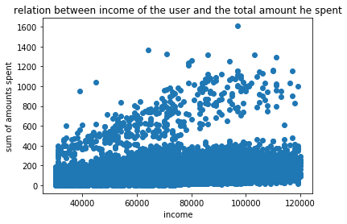

```python
plt.scatter(data = transaction_amount ,x = 'income' , y ='amount' , color  = color);
plt.xlabel('income');
plt.ylabel('sum of amounts spent');
plt.title('relation between income of the user and the total amount he spent')
```

# Preparing data for machine learning models

```python
offer_df.head()
```

|  | event | person | time | offer_id |
| --- | --- | --- | --- | --- |
| 0 | offer received | 78afa995795e4d85b5d9ceeca43f5fef | 0 | 9b98b8c7a33c4b65b9aebfe6a799e6d9 |
| 2 | offer received | e2127556f4f64592b11af22de27a7932 | 0 | 2906b810c7d4411798c6938adc9daaa5 |
| 5 | offer received | 389bc3fa690240e798340f5a15918d5c | 0 | f19421c1d4aa40978ebb69ca19b0e20d |
| 7 | offer received | 2eeac8d8feae4a8cad5a6af0499a211d | 0 | 3f207df678b143eea3cee63160fa8bed |
| 8 | offer received | aa4862eba776480b8bb9c68455b8c2e1 | 0 | 0b1e1539f2cc45b7b9fa7c272da2e1d7 |

Merging offer data and profile data

```python
offer_profile = pd.merge(left = offer_df ,right = profile , how = 'left' , left_on ='person' ,right_on = 'user_id')
offer_profile.head()
```

|  | event | person | time | offer_id | age | became_member_on | gender | user_id | income |
| --- | --- | --- | --- | --- | --- | --- | --- | --- | --- |
| 0 | offer received | 78afa995795e4d85b5d9ceeca43f5fef | 0 | 9b98b8c7a33c4b65b9aebfe6a799e6d9 | 75 | 2017-05-09 | F | 78afa995795e4d85b5d9ceeca43f5fef | 100000.0 |
| 1 | offer received | e2127556f4f64592b11af22de27a7932 | 0 | 2906b810c7d4411798c6938adc9daaa5 | 68 | 2018-04-26 | M | e2127556f4f64592b11af22de27a7932 | 70000.0 |
| 2 | offer received | 389bc3fa690240e798340f5a15918d5c | 0 | f19421c1d4aa40978ebb69ca19b0e20d | 65 | 2018-02-09 | M | 389bc3fa690240e798340f5a15918d5c | 53000.0 |
| 3 | offer received | 2eeac8d8feae4a8cad5a6af0499a211d | 0 | 3f207df678b143eea3cee63160fa8bed | 58 | 2017-11-11 | M | 2eeac8d8feae4a8cad5a6af0499a211d | 51000.0 |
| 4 | offer received | aa4862eba776480b8bb9c68455b8c2e1 | 0 | 0b1e1539f2cc45b7b9fa7c272da2e1d7 | 61 | 2017-09-11 | F | aa4862eba776480b8bb9c68455b8c2e1 | 57000.0 |

```python
offer_profile.isna().all().all()
```

```
False
```

- Creating dummy variables for categorical (gender) and multivalued features event , and creating dummy for years in became_member_on only

```python
offer_profile =pd.get_dummies(data =offer_profile , columns= ['event'])
```

```python
offer_profile =pd.get_dummies(data =offer_profile , columns= ['gender'])
```

```python
offer_profile['became_member_on'] = pd.to_datetime(profile['became_member_on'],exact = True , format = '%Y%m%d')
```

```python
offer_profile['year'] = offer_profile['became_member_on'].dt.year
```

```python
offer_profile = pd.get_dummies(data =offer_profile , columns= ['year'])
```

```python
offer_profile.head()
```

|  | person | time | offer_id | age | became_member_on | user_id | income | event_offer completed | event_offer received | event_offer viewed | gender_F | gender_M | gender_O | year_2013 | year_2014 | year_2015 | year_2016 | year_2017 | year_2018 |
| --- | --- | --- | --- | --- | --- | --- | --- | --- | --- | --- | --- | --- | --- | --- | --- | --- | --- | --- | --- |
| 0 | 78afa995795e4d85b5d9ceeca43f5fef | 0 | 9b98b8c7a33c4b65b9aebfe6a799e6d9 | 75 | 2017-05-09 | 78afa995795e4d85b5d9ceeca43f5fef | 100000.0 | 0 | 1 | 0 | 1 | 0 | 0 | 0 | 0 | 0 | 0 | 1 | 0 |
| 1 | e2127556f4f64592b11af22de27a7932 | 0 | 2906b810c7d4411798c6938adc9daaa5 | 68 | 2018-04-26 | e2127556f4f64592b11af22de27a7932 | 70000.0 | 0 | 1 | 0 | 0 | 1 | 0 | 0 | 0 | 0 | 0 | 0 | 1 |
| 2 | 389bc3fa690240e798340f5a15918d5c | 0 | f19421c1d4aa40978ebb69ca19b0e20d | 65 | 2018-02-09 | 389bc3fa690240e798340f5a15918d5c | 53000.0 | 0 | 1 | 0 | 0 | 1 | 0 | 0 | 0 | 0 | 0 | 0 | 1 |
| 3 | 2eeac8d8feae4a8cad5a6af0499a211d | 0 | 3f207df678b143eea3cee63160fa8bed | 58 | 2017-11-11 | 2eeac8d8feae4a8cad5a6af0499a211d | 51000.0 | 0 | 1 | 0 | 0 | 1 | 0 | 0 | 0 | 0 | 0 | 1 | 0 |
| 4 | aa4862eba776480b8bb9c68455b8c2e1 | 0 | 0b1e1539f2cc45b7b9fa7c272da2e1d7 | 61 | 2017-09-11 | aa4862eba776480b8bb9c68455b8c2e1 | 57000.0 | 0 | 1 | 0 | 1 | 0 | 0 | 0 | 0 | 0 | 0 | 1 | 0 |

```python
offer_profile.drop(axis = 1 , labels=['person'],inplace = True)
```

```python
all_data = pd.merge(left = offer_profile , right = portfolio ,left_on = 'offer_id' , right_on = 'offer_id' , how = 'inner' )
all_data.head(4)
```

|  | time | offer_id | age | became_member_on | user_id | income | event_offer completed | event_offer received | event_offer viewed | gender_F | ... | difficulty | duration | reward | offer_type_bogo | offer_type_discount | offer_type_informational | web | email | social | mobile |
| --- | --- | --- | --- | --- | --- | --- | --- | --- | --- | --- | --- | --- | --- | --- | --- | --- | --- | --- | --- | --- | --- |
| 0 | 0 | 9b98b8c7a33c4b65b9aebfe6a799e6d9 | 75 | 2017-05-09 | 78afa995795e4d85b5d9ceeca43f5fef | 100000.0 | 0 | 1 | 0 | 1 | ... | 5 | 7 | 5 | 1 | 0 | 0 | 1 | 1 | 0 | 1 |
| 1 | 0 | 9b98b8c7a33c4b65b9aebfe6a799e6d9 | 59 | 2015-01-21 | ebe7ef46ea6f4963a7dd49f501b26779 | 41000.0 | 0 | 1 | 0 | 0 | ... | 5 | 7 | 5 | 1 | 0 | 0 | 1 | 1 | 0 | 1 |
| 2 | 0 | 9b98b8c7a33c4b65b9aebfe6a799e6d9 | 40 | 2016-07-09 | f082d80f0aac47a99173ba8ef8fc1909 | 33000.0 | 0 | 1 | 0 | 0 | ... | 5 | 7 | 5 | 1 | 0 | 0 | 1 | 1 | 0 | 1 |
| 3 | 0 | 9b98b8c7a33c4b65b9aebfe6a799e6d9 | 45 | 2018-07-07 | c0d210398dee4a0895b24444a5fcd1d2 | 33000.0 | 0 | 1 | 0 | 0 | ... | 5 | 7 | 5 | 1 | 0 | 0 | 1 | 1 | 0 | 1 |

4 rows × 29 columns

```python
all_data.drop(axis = 1 ,labels = 'became_member_on' , inplace =True)
```

```python
all_data.to_csv('final_data.csv' , index = False)
```

```python
all_data = pd.read_csv('final_data.csv')
```

- I will create 3 data one for each offer type
- and also consider only viewed offer for each type as success ,,because completed offer with no view does not represent influence of offer

```python
all_data.columns
```

```
Index(['time', 'offer_id', 'age', 'user_id', 'income', 'event_offer completed',
       'event_offer received', 'event_offer viewed', 'gender_F', 'gender_M',
       'gender_O', 'year_2013', 'year_2014', 'year_2015', 'year_2016',
       'year_2017', 'year_2018', 'channels', 'difficulty', 'duration',
       'reward', 'offer_type_bogo', 'offer_type_discount',
       'offer_type_informational', 'web', 'email', 'social', 'mobile'],
      dtype='object')
```

# Creating 3 data set one for each offer type (BOGO , discount ,informational)

**BOGO data**

```python
all_data_bogo = all_data.query('offer_type_bogo == 1')
all_data_bogo['response'] = all_data_bogo['event_offer viewed'].apply(lambda x :1 if x ==1 else 0)
```

```
C:\Users\eng basel\Anaconda3\lib\site-packages\ipykernel_launcher.py:2: SettingWithCopyWarning:
A value is trying to be set on a copy of a slice from a DataFrame.
Try using .loc[row_indexer,col_indexer] = value instead

See the caveats in the documentation: http://pandas.pydata.org/pandas-docs/stable/indexing.html#indexing-view-versus-copy
```

```python
bogo_users = all_data_bogo['user_id']
```

```python
all_data_bogo.drop(axis = 1 ,labels = ['offer_id', 'user_id' ,'channels' , 'offer_type_bogo', 'offer_type_discount',
       'offer_type_informational' ] , inplace= True)
```

```
C:\Users\eng basel\Anaconda3\lib\site-packages\ipykernel_launcher.py:2: SettingWithCopyWarning:
A value is trying to be set on a copy of a slice from a DataFrame

See the caveats in the documentation: http://pandas.pydata.org/pandas-docs/stable/indexing.html#indexing-view-versus-copy
```

**discount data**

```python
all_data_discount = all_data.query('offer_type_discount == 1')
all_data_discount['response'] = all_data_discount['event_offer viewed'].apply(lambda x :1 if x ==1 else 0)
discount_users = all_data_discount['user_id']
all_data_discount.drop(axis = 1 ,labels = ['offer_id', 'user_id' ,'channels' , 'offer_type_bogo', 'offer_type_discount',
       'offer_type_informational' ] , inplace= True)
```

```
C:\Users\eng basel\Anaconda3\lib\site-packages\ipykernel_launcher.py:2: SettingWithCopyWarning:
A value is trying to be set on a copy of a slice from a DataFrame.
Try using .loc[row_indexer,col_indexer] = value instead

See the caveats in the documentation: http://pandas.pydata.org/pandas-docs/stable/indexing.html#indexing-view-versus-copy

C:\Users\eng basel\Anaconda3\lib\site-packages\ipykernel_launcher.py:5: SettingWithCopyWarning:
A value is trying to be set on a copy of a slice from a DataFrame

See the caveats in the documentation: http://pandas.pydata.org/pandas-docs/stable/indexing.html#indexing-view-versus-copy
  """
```

**informational data**

```python
all_data_informational = all_data.query('offer_type_informational == 1')
all_data_informational['response'] = all_data_informational['event_offer viewed'].apply(lambda x :1 if x ==1 else 0)
informational_users = all_data_informational['user_id']
all_data_informational.drop(axis = 1 ,labels = ['offer_id', 'user_id' ,'channels' , 'offer_type_bogo', 'offer_type_discount',
       'offer_type_informational' ] , inplace= True)
```

```
C:\Users\eng basel\Anaconda3\lib\site-packages\ipykernel_launcher.py:2: SettingWithCopyWarning:
A value is trying to be set on a copy of a slice from a DataFrame.
Try using .loc[row_indexer,col_indexer] = value instead

See the caveats in the documentation: http://pandas.pydata.org/pandas-docs/stable/indexing.html#indexing-view-versus-copy

C:\Users\eng basel\Anaconda3\lib\site-packages\ipykernel_launcher.py:5: SettingWithCopyWarning:
A value is trying to be set on a copy of a slice from a DataFrame

See the caveats in the documentation: http://pandas.pydata.org/pandas-docs/stable/indexing.html#indexing-view-versus-copy
  """
```

# for each data of the 3 data we will run a binary classifier to predict if each is suitable for the user or not

# Bogo data model

- droping response variable from all_data_bogo and use it as label
- we will split data into train and test with percentage 20%

```python
Y = all_data_bogo['response']

all_data_bogo.drop(axis = 1 , labels = ['response'], inplace = True)
```

```
C:\Users\eng basel\Anaconda3\lib\site-packages\ipykernel_launcher.py:2: SettingWithCopyWarning:
A value is trying to be set on a copy of a slice from a DataFrame

See the caveats in the documentation: http://pandas.pydata.org/pandas-docs/stable/indexing.html#indexing-view-versus-copy
```

```python
def splitting(data, Y):
    scaler = StandardScaler()
    standard_data = scaler.fit_transform(data)
    X_train, X_test, Y_train, Y_test = train_test_split(standard_data, Y , test_size = 0.20 , shuffle = True , random_state = 1)
    return (X_train, X_test, Y_train, Y_test)
```

```python
def train_model(X_train , Y_train):
    scorer = make_scorer(f1_score)

    parameters_svc={'kernel':['linear'],'C':[10 ,20]}
    parameters_log_reg={'C':[1.2],'max_iter':[1500]}

    grid_svc=GridSearchCV(estimator=SVC(),param_grid=parameters_svc,scoring=scorer,cv=2)
    grid_log_reg = GridSearchCV(estimator=LogisticRegression(),param_grid=parameters_log_reg,scoring=scorer,cv=2)

    svc_results = grid_svc.fit(X_train,Y_train)
    log_reg_results = grid_log_reg.fit(X_train,Y_train)
    return (grid_svc , grid_log_reg)
```

```python
X_train_bogo, X_test_bogo, Y_train_bogo, Y_test_bogo = splitting(all_data_bogo,Y)
```

```python
svc , log_reg = train_model(X_train_bogo , Y_train_bogo)
```

```python
print(svc.cv_results_)
print(log_reg.cv_results_)
```

[output not shown]

```python
test_score = svc.score(X_test_bogo ,Y_test_bogo )
test_score
```

```
1.0
```

# Discount data model

```python
Y_discount = all_data_discount['response']

all_data_discount.drop(axis = 1 , labels = ['response'], inplace = True)
```

```
C:\Users\eng basel\Anaconda3\lib\site-packages\ipykernel_launcher.py:4: SettingWithCopyWarning:
A value is trying to be set on a copy of a slice from a DataFrame

See the caveats in the documentation: http://pandas.pydata.org/pandas-docs/stable/indexing.html#indexing-view-versus-copy
  after removing the cwd from sys.path.
```

```python
X_train_discount , X_test_discount , Y_train_discount ,Y_test_discount = splitting(all_data_discount, Y_discount)
```

```python
svc_discount , log_reg_discount = train_model(X_train_discount , Y_train_discount)
```

```python
svc_discount.cv_results_
```

[output not shown]

```
{'mean_fit_time': array([0.03452122, 0.0345248 ]),
 'mean_score_time': array([0.0295217 , 0.02802992]),
 'mean_test_score': array([1., 1.]),
 'mean_train_score': array([1., 1.]),
 'param_C': masked_array(data=[10, 20],
              mask=[False, False],
        fill_value='?',
             dtype=object),
 'param_kernel': masked_array(data=['linear', 'linear'],
              mask=[False, False],
        fill_value='?',
             dtype=object),
 'params': [{'C': 10, 'kernel': 'linear'}, {'C': 20, 'kernel': 'linear'}],
 'rank_test_score': array([1, 1]),
 'split0_test_score': array([1., 1.]),
 'split0_train_score': array([1., 1.]),
 'split1_test_score': array([1., 1.]),
 'split1_train_score': array([1., 1.]),
 'std_fit_time': array([0.00349867, 0.00150144]),
 'std_score_time': array([0.00750637, 0.00201201]),
 'std_test_score': array([0., 0.]),
 'std_train_score': array([0., 0.])}
```

```python
test_score_discount = svc_discount.score(X_test_discount ,Y_test_discount )
test_score_discount
```

```
1.0
```

# Informational data model

```python
Y_informational = all_data_informational['response']

all_data_informational.drop(axis = 1 , labels = ['response'], inplace = True)
```

```
C:\Users\eng basel\Anaconda3\lib\site-packages\ipykernel_launcher.py:3: SettingWithCopyWarning:
A value is trying to be set on a copy of a slice from a DataFrame

See the caveats in the documentation: http://pandas.pydata.org/pandas-docs/stable/indexing.html#indexing-view-versus-copy
  This is separate from the ipykernel package so we can avoid doing imports until
```

```python
X_train_informational , X_test_informational , Y_train_informational ,Y_test_informational = splitting(all_data_informational, Y_informational)
```

```python
svc_informational , log_reg_informational = train_model(X_train_informational , Y_train_informational)
```

```python
svc_informational.cv_results_
```

[output not shown]

```
{'mean_fit_time': array([0.01051807, 0.01251173]),
 'mean_score_time': array([0.01099491, 0.00950468]),
 'mean_test_score': array([1., 1.]),
 'mean_train_score': array([1., 1.]),
 'param_C': masked_array(data=[10, 20],
              mask=[False, False],
        fill_value='?',
             dtype=object),
 'param_kernel': masked_array(data=['linear', 'linear'],
              mask=[False, False],
        fill_value='?',
             dtype=object),
 'params': [{'C': 10, 'kernel': 'linear'}, {'C': 20, 'kernel': 'linear'}],
 'rank_test_score': array([1, 1]),
 'split0_test_score': array([1., 1.]),
 'split0_train_score': array([1., 1.]),
 'split1_test_score': array([1., 1.]),
 'split1_train_score': array([1., 1.]),
 'std_fit_time': array([0.00149131, 0.00350523]),
 'std_score_time': array([0.00101042, 0.0004977 ]),
 'std_test_score': array([0., 0.]),
 'std_train_score': array([0., 0.])}
```

```python
log_reg_informational.cv_results_
```

[output not shown]

```
{'mean_fit_time': array([0.03602576]),
 'mean_score_time': array([0.00400245]),
 'mean_test_score': array([1.]),
 'mean_train_score': array([1.]),
 'param_C': masked_array(data=[1.2],
              mask=[False],
        fill_value='?',
             dtype=object),
 'param_max_iter': masked_array(data=[1500],
              mask=[False],
        fill_value='?',
             dtype=object),
 'params': [{'C': 1.2, 'max_iter': 1500}],
 'rank_test_score': array([1]),
 'split0_test_score': array([1.]),
 'split0_train_score': array([1.]),
 'split1_test_score': array([1.]),
 'split1_train_score': array([1.]),
 'std_fit_time': array([0.00300169]),
 'std_score_time': array([3.57627869e-07]),
 'std_test_score': array([0.]),
 'std_train_score': array([0.])}
```

```python
test_informational_pred = svc_informational.predict(X_test_informational)
```

```python
test_score_informational = svc_informational.score(X_test_informational ,Y_test_informational )
test_score
```

```
1.0
```

# Now for any new user with certain features like age or income we will run the 3 trained classifiers logestic regression or SVM for( bogo , discount ,informational) and see which one give the highest prediction

# refrences

https://github.com/gauravansal/Starbucks-Capstone-Challenge/blob/master/Starbucks_Capstone_notebook.ipynb

https://github.com/tahsinac/starbucks-offers